# Null_Jack_Project_2

## Import Libraries

```python
import pandas as pd
import numpy as np
import matplotlib.pyplot as plt
import statsmodels.api as sm
import seaborn as sns
import scipy as sp
from statsmodels.stats.diagnostic import acorr_ljungbox
from statsmodels.graphics.tsaplots import plot_acf, plot_pacf
from statsmodels.tsa.stattools import adfuller
from statsmodels.graphics.tsaplots import plot_predict
from statsmodels.tsa.arima.model import ARIMA
from statsmodels.tsa.arima.model import ARIMAResults
from scipy.signal import detrend
```

```python
data_path = '/content/Baggage_Info_American.xlsx'
american_df = pd.read_excel(data_path)
american_df.info()
```

```
<class 'pandas.core.frame.DataFrame'>
RangeIndex: 82 entries, 0 to 81
Data columns (total 8 columns):
 #   Column     Non-Null Count  Dtype
---  ------     --------------  -----
 0   Airline    82 non-null     object
 1   Date       82 non-null     datetime64[ns]
 2   Month      82 non-null     int64
 3   Year       82 non-null     int64
 4   Baggage    82 non-null     int64
 5   Scheduled  82 non-null     int64
 6   Cancelled  82 non-null     int64
 7   Enplaned   82 non-null     int64
dtypes: datetime64[ns](1), int64(6), object(1)
memory usage: 5.2+ KB
```

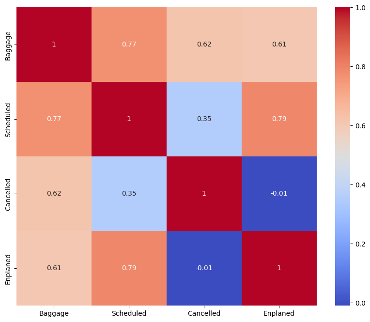

```python
bag_dat_sub = american_df.drop(columns=['Airline', 'Date', 'Month', 'Year'])


# Compute correlations
cormat = bag_dat_sub.corr()

# Round correlation matrix to 2 decimal places
cormat = cormat.round(2)

# Plot correlation matrix using a heatmap
plt.figure(figsize = (10,8))
sns.heatmap(cormat,annot=True, cmap = 'coolwarm')
plt.show()
```

## We start by looking at the American Airlines Baggage Claim Data

## Create a monthly index for the series

```python
american_df['Date'] = pd.to_datetime(american_df['Date'], format="%b-%y")
american_bag_ts = pd.Series(american_df['Baggage'].values, index=american_df['Date'])
american_bag_ts.index.freq = 'MS'
```

## Plot the American baggage claims series

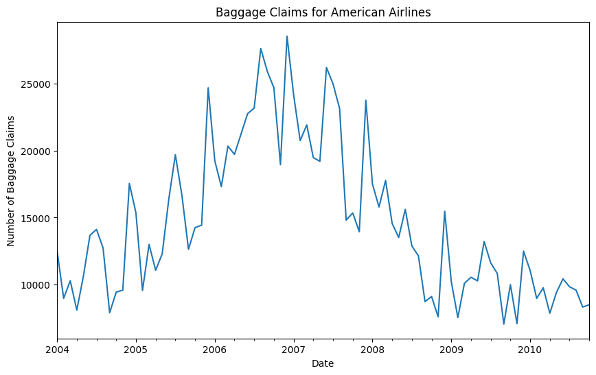

```python
plt.figure(figsize=(10, 6))
american_bag_ts.plot()
plt.title("Baggage Claims for American Airlines")
plt.xlabel("Date")
plt.ylabel("Number of Baggage Claims")
plt.show()
```

## Conduct Ljung Box test on the American Airlines Baggage Claims series using 10 lags to see if the series is white noise

```python
american_bags = american_df[['Baggage']]

sm.stats.acorr_ljungbox(american_bags, lags=[10], return_df=True)
```

|  | lb_stat | lb_pvalue |
| --- | --- | --- |
| 10 | 345.847732 | 3.029922e-68 |

## Since the p-value is near zero, we reject the null hypothesis and conclude that the series is not white noise.

## Next, we will plot the ACF and PACF for the American Airlines Baggage Claims series

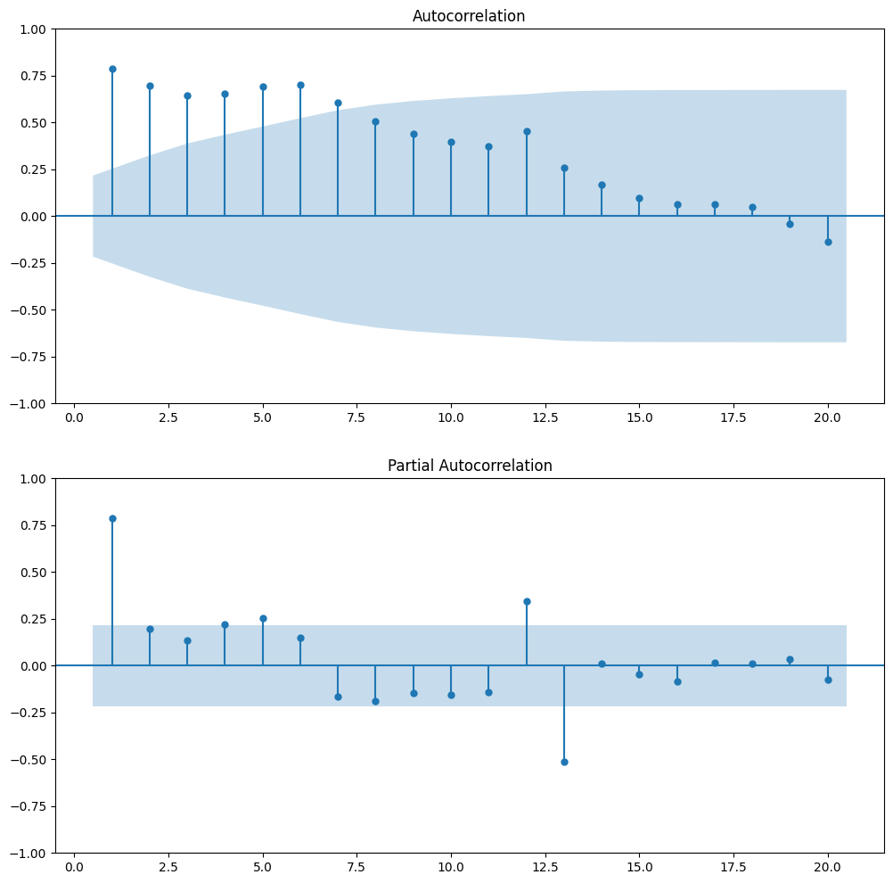

```python
fig, (ax1, ax2) = plt.subplots(2, 1, figsize=(12, 12))
plot_acf(american_bag_ts, ax=ax1, zero=False)
plot_pacf(american_bag_ts, ax=ax2, zero=False)
plt.show()
```

## We see that there is seasonality in the data set, so we will take a 12-month seasonal difference.

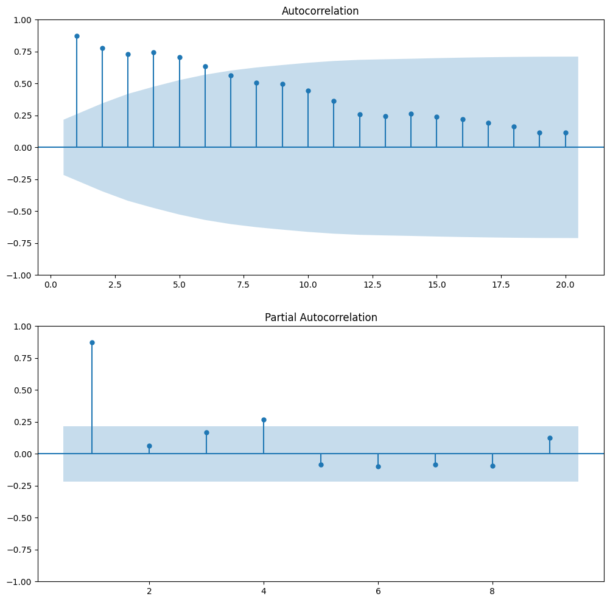

```python
# Fit ARIMA(0,0,0)x(0,1,0)[12] model to the data - This is simply taking the 12-month seasonal difference

fit_ARD12 = ARIMA(american_bag_ts, order=(0,0,0), seasonal_order=(0, 1, 0, 12)).fit()

# Plot ACF and PACF for residuals from the seasonal difference in order to
# assess the correlation still remaining in the data

residuals12 = fit_ARD12.resid

fig, (ax1, ax2) = plt.subplots(2, 1, figsize=(12, 12))
plot_acf(residuals12, ax=ax1, zero=False)
plot_pacf(residuals12, ax=ax2, zero=False, lags=9)
plt.show()
```

## Now, we see that by taking a 12-month seasonal difference, our time series looks like it has an AR signature.

## We will now fit an ARIMA model to the data:

```
                                     SARIMAX Results
==========================================================================================
Dep. Variable:                                  y   No. Observations:                   82
Model:             ARIMA(1, 0, 0)x(0, 1, [1], 12)   Log Likelihood                -650.147
Date:                            Mon, 16 Oct 2023   AIC                           1306.295
Time:                                    12:14:32   BIC                           1313.040
Sample:                                01-01-2004   HQIC                          1308.974
                                     - 10-01-2010
Covariance Type:                              opg
==============================================================================
                 coef    std err          z      P>|z|      [0.025      0.975]
------------------------------------------------------------------------------
ar.L1          0.9306      0.026     35.513      0.000       0.879       0.982
ma.S.L12      -0.8417      0.163     -5.160      0.000      -1.161      -0.522
sigma2      5.372e+06   2.61e-08   2.06e+14      0.000    5.37e+06    5.37e+06
===================================================================================
Ljung-Box (L1) (Q):                   0.21   Jarque-Bera (JB):                 6.17
Prob(Q):                              0.65   Prob(JB):                         0.05
Heteroskedasticity (H):               0.18   Skew:                            -0.19
Prob(H) (two-sided):                  0.00   Kurtosis:                         4.41
===================================================================================

Warnings:
[1] Covariance matrix calculated using the outer product of gradients (complex-step).
[2] Covariance matrix is singular or near-singular, with condition number 2.66e+29. Standard errors may be unstable.
```

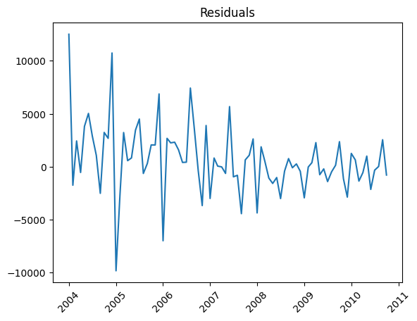

```
<statsmodels.tsa.statespace.mlemodel.PredictionResultsWrapper object at 0x7ac7163f0e80>
```

```python
# Fit ARIMA(1,0,0)x(0,1,1)[12] model to the data

#Best model for Baggage Complaints for American is ARIMA(1,0,0)x(0,1,1)[12]
fit_AR1 = ARIMA(american_bag_ts, order=(1,0,0), seasonal_order=(0, 1, 1, 12)).fit()


# Summary of the ARIMA model
print(fit_AR1.summary())

# Examine residuals from the model
residuals = fit_AR1.resid
plt.plot(residuals)
plt.title('Residuals')
plt.xticks(rotation=45)
plt.show()

#Generate the predicted values for the series
pred_units = fit_AR1.get_prediction()
print(pred_units)
```

## Plot the ACF and PACF for the residuals

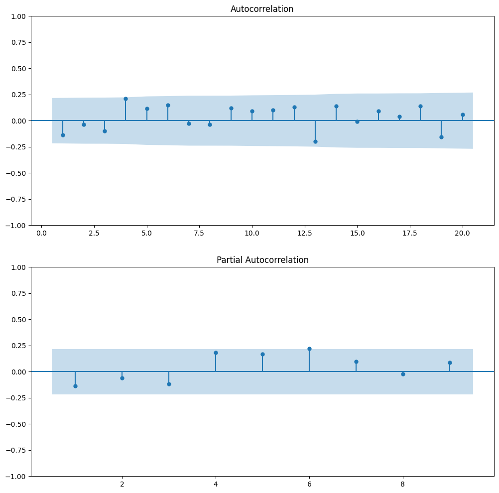

```python
fig, (ax1, ax2) = plt.subplots(2, 1, figsize=(12, 12))
plot_acf(residuals, ax=ax1, zero=False)
plot_pacf(residuals, ax=ax2, zero=False, lags=9)
plt.show()
```

## Conduct a Ljung Box test on the residuals to test for white noise

```python
sm.stats.acorr_ljungbox(residuals, lags=[10], return_df=True)
```

|  | lb_stat | lb_pvalue |
| --- | --- | --- |
| 10 | 12.000423 | 0.285028 |

## Looking at the ACF, PACF, and the results from our Ljung-Box test (fail to reject the null hypothesis that the series is white noise since 0.285 > 0.05), we conclude that this is a reasonable model.

## Next, we will compute the forecast error

```python
predicted_mean = pred_units.predicted_mean
conf_int = pred_units.conf_int()

prediction_df = pd.DataFrame({
    'predicted_mean': predicted_mean,
    'lower_bound': conf_int.iloc[:, 0],
    'upper_bound': conf_int.iloc[:, 1]
})
prediction_df = prediction_df.tail(-1)
prediction_df.head()
```

| Date | predicted_mean | lower_bound | upper_bound |
| --- | --- | --- | --- |
| 2004-02-01 | 10726.464597 | 4277.011704 | 17175.917490 |
| 2004-03-01 | 7859.183802 | 1413.186205 | 14305.181399 |
| 2004-04-01 | 8640.188576 | 2199.562209 | 15080.814944 |
| 2004-05-01 | 6808.654738 | 376.417995 | 13240.891481 |
| 2004-06-01 | 8654.599917 | 2232.591910 | 15076.607923 |

```python
prediction_df = pd.concat([prediction_df,american_bag_ts.to_frame(name='Baggage')],axis=1)
prediction_df = prediction_df.tail(-1)
prediction_df.head()
```

| Date | predicted_mean | lower_bound | upper_bound | Baggage |
| --- | --- | --- | --- | --- |
| 2004-02-01 | 10726.464597 | 4277.011704 | 17175.917490 | 8977 |
| 2004-03-01 | 7859.183802 | 1413.186205 | 14305.181399 | 10289 |
| 2004-04-01 | 8640.188576 | 2199.562209 | 15080.814944 | 8095 |
| 2004-05-01 | 6808.654738 | 376.417995 | 13240.891481 | 10618 |
| 2004-06-01 | 8654.599917 | 2232.591910 | 15076.607923 | 13684 |

## Calculate the Forecast Error

```python
# calc error
errors = prediction_df['Baggage'] - prediction_df['predicted_mean']
# absolue value of error
errors_abs = errors.abs()
# -- mape --
mape = (errors_abs/prediction_df['Baggage'].abs()).mean()
# -- rmse
rmse = (errors**2).mean()**0.5
# -- print it out
print(f'MAPE = {mape:.3%}')
print(f'RMSE = {rmse:,.3f}')
```

```
MAPE = 14.439%
RMSE = 2,990.367
```

## Our forecast yields a MAPE of 14.439%, which is good considering how noisy this dataset is.

## Now, we will generate a forecast of values for the next 6 months:

```python
forecast = fit_AR1.get_forecast(steps=6)
mean_forecast = forecast.predicted_mean
confidence_intervals = forecast.conf_int()
forecast_df = pd.DataFrame({
    'Forecasted_Claims': mean_forecast,
    'Lower_Bound': confidence_intervals.iloc[:, 0],
    'Upper_Bound': confidence_intervals.iloc[:, 1]
})

forecast_df
```

|  | Forecasted_Claims | Lower_Bound | Upper_Bound |
| --- | --- | --- | --- |
| 2010-11-01 | 6610.687786 | 2000.918728 | 11220.456843 |
| 2010-12-01 | 14368.705403 | 8083.000251 | 20654.410555 |
| 2011-01-01 | 11788.592753 | 4360.624724 | 19216.560782 |
| 2011-02-01 | 9130.519721 | 839.755049 | 17421.284392 |
| 2011-03-01 | 11018.683378 | 2049.302310 | 19988.064447 |
| 2011-04-01 | 9484.628520 | -32.342362 | 19001.599402 |

## We will now plot the series with our 6 month forecast:

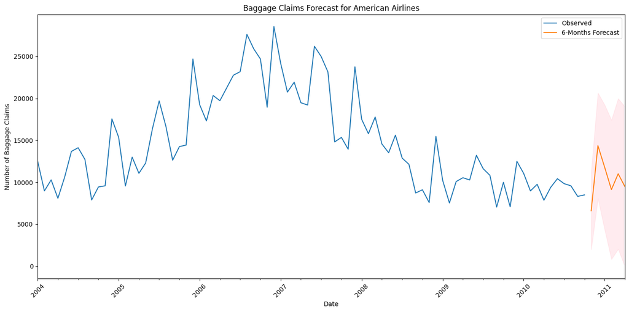

```python
plt.figure(figsize=(14, 7))
american_bag_ts.plot(label='Observed', legend=True)
mean_forecast.plot(label='6-Months Forecast', legend=True)
plt.fill_between(confidence_intervals.index,
                 confidence_intervals.iloc[:, 0],
                 confidence_intervals.iloc[:, 1], color='pink', alpha=0.3)
plt.title("Baggage Claims Forecast for American Airlines")
plt.xlabel("Date")
plt.ylabel("Number of Baggage Claims")
plt.xticks(rotation=45)
plt.tight_layout()
plt.legend()
plt.show()
```

## We will now look at the Cancelled flight data for American Airlines

```python
# Create a monthly index for the series
american_df['Date'] = pd.to_datetime(american_df['Date'], format="%b-%y")
american_cancelled_ts = pd.Series(american_df['Cancelled'].values, index=american_df['Date'])
american_cancelled_ts.index.freq = 'MS'
```

## Plot the series

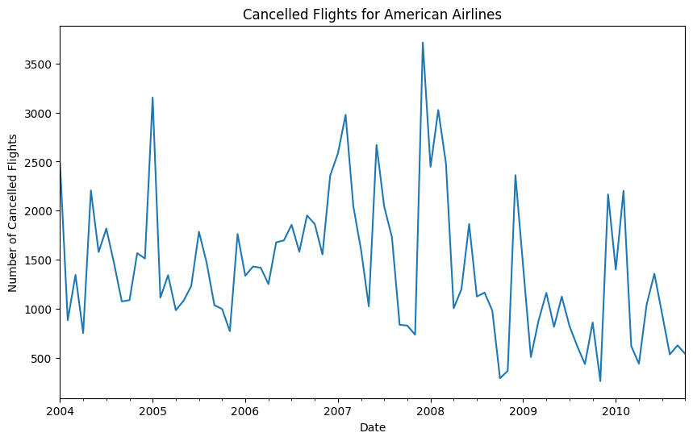

```python
plt.figure(figsize=(10, 6))
american_cancelled_ts.plot()
plt.title("Cancelled Flights for American Airlines")
plt.xlabel("Date")
plt.ylabel("Number of Cancelled Flights")
plt.show()
```

## Conduct Ljung Box test on the American Airlines Cancelled Flight series using 10 lags to see if the series is white noise

```python
american_cancelled = american_df[['Cancelled']]

sm.stats.acorr_ljungbox(american_cancelled, lags=[10], return_df=True)
```

|  | lb_stat | lb_pvalue |
| --- | --- | --- |
| 10 | 32.726621 | 0.000303 |

## Since the p-value is near zero, we reject the null hypothesis and conclude that the series is not white noise.

## Next, we will plot the ACF and PACF for the American Airlines Cancelled Flights series

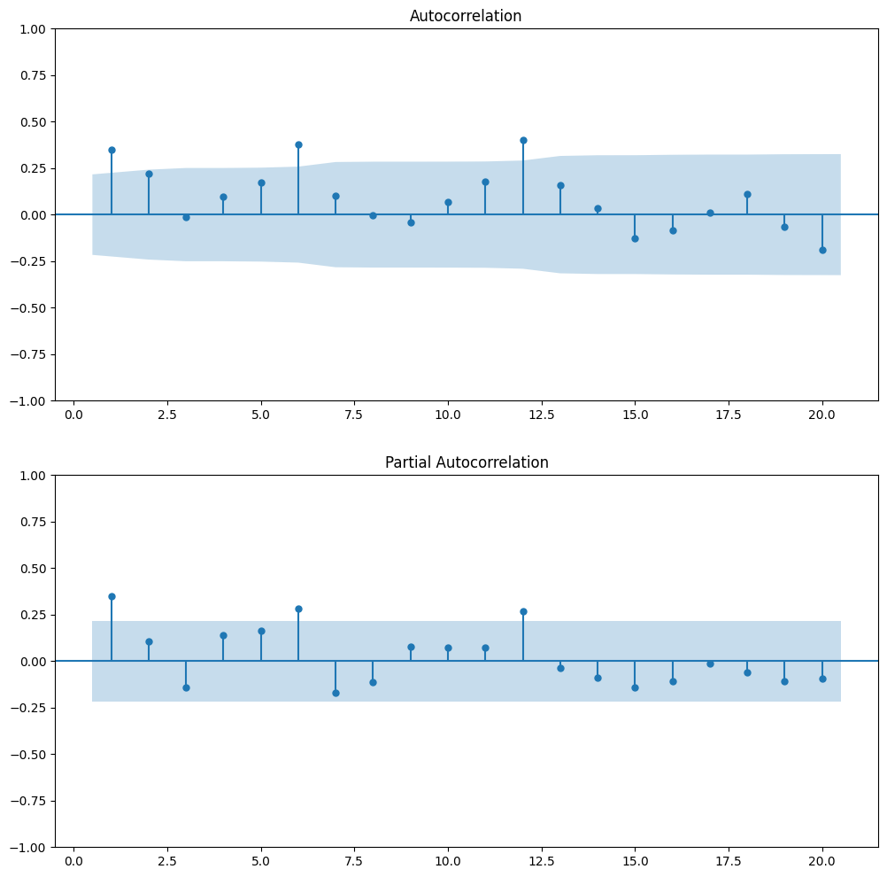

```python
fig, (ax1, ax2) = plt.subplots(2, 1, figsize=(12, 12))
plot_acf(american_cancelled_ts, ax=ax1, zero=False)
plot_pacf(american_cancelled_ts, ax=ax2, zero=False)
plt.show()
```

## Since there is seasonality in this data, we will take a 12-month seasonal difference:

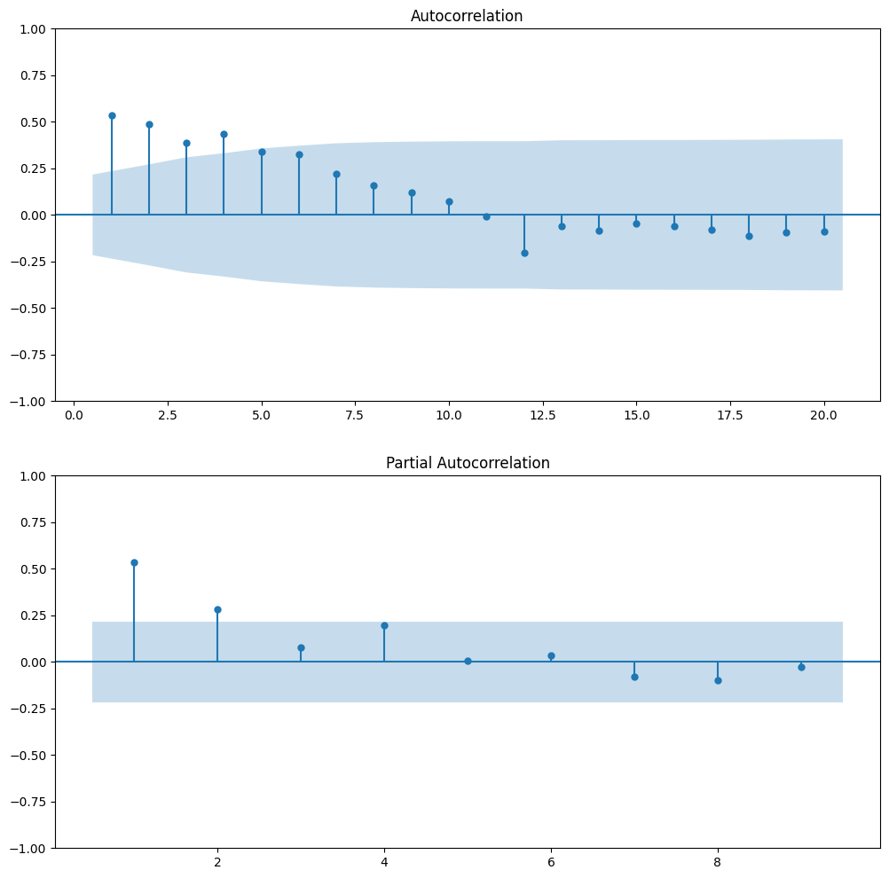

```python
fit_ARD12_american_cancelled = ARIMA(american_cancelled_ts, order=(0,0,0), seasonal_order=(0, 1, 0, 12)).fit()

# Plot ACF and PACF for residuals from the seasonal difference in order to
# assess the correlation still remaining in the data

residuals12_american_cancelled = fit_ARD12_american_cancelled.resid

fig, (ax1, ax2) = plt.subplots(2, 1, figsize=(12, 12))
plot_acf(residuals12_american_cancelled, ax=ax1, zero=False)
plot_pacf(residuals12_american_cancelled, ax=ax2, zero=False, lags=9)
plt.show()
```

## We see in the ACF and PACF that by taking a 12-month seasonal difference, our time series has an AR signature

## We will fit an ARIMA(0,1,1)x(2,1,0)[12] model to the American Cancelled Flights data:

```
                                     SARIMAX Results
=========================================================================================
Dep. Variable:                                 y   No. Observations:                   82
Model:             ARIMA(0, 1, 1)x(2, 1, [], 12)   Log Likelihood                -541.529
Date:                           Mon, 16 Oct 2023   AIC                           1091.059
Time:                                   12:14:37   BIC                           1099.995
Sample:                               01-01-2004   HQIC                          1094.604
                                    - 10-01-2010
Covariance Type:                             opg
==============================================================================
                 coef    std err          z      P>|z|      [0.025      0.975]
------------------------------------------------------------------------------
ma.L1         -0.7455      0.078     -9.521      0.000      -0.899      -0.592
ar.S.L12      -0.5716      0.126     -4.523      0.000      -0.819      -0.324
ar.S.L24      -0.3009      0.125     -2.398      0.016      -0.547      -0.055
sigma2       3.67e+05   5.63e+04      6.518      0.000    2.57e+05    4.77e+05
===================================================================================
Ljung-Box (L1) (Q):                   0.08   Jarque-Bera (JB):                 4.28
Prob(Q):                              0.78   Prob(JB):                         0.12
Heteroskedasticity (H):               1.03   Skew:                             0.23
Prob(H) (two-sided):                  0.94   Kurtosis:                         4.13
===================================================================================

Warnings:
[1] Covariance matrix calculated using the outer product of gradients (complex-step).
```

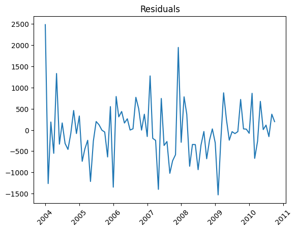

```
<statsmodels.tsa.statespace.mlemodel.PredictionResultsWrapper object at 0x7ac7125b81f0>
```

```python
fit_AR1_cancelled = ARIMA(american_cancelled_ts, order=(0,1,1), seasonal_order=(2, 1, 0, 12)).fit()

# Summary of the ARIMA model
print(fit_AR1_cancelled.summary())

# Examine residuals from the model
residuals = fit_AR1_cancelled.resid
plt.plot(residuals)
plt.title('Residuals')
plt.xticks(rotation=45)
plt.show()

#Generate the predicted values for the series
pred_units = fit_AR1_cancelled.get_prediction()
print(pred_units)
```

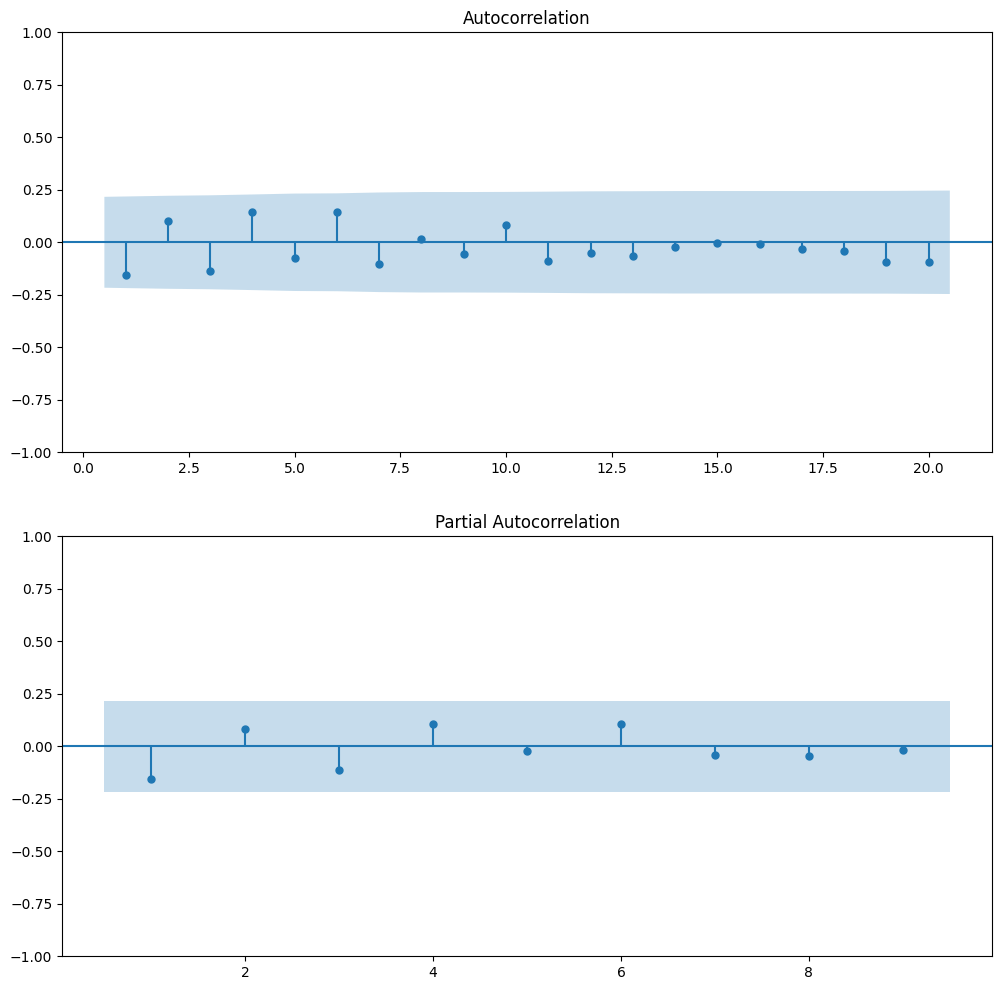

```python
# Plot ACF and PACF for residuals
fig, (ax1, ax2) = plt.subplots(2, 1, figsize=(12, 12))
plot_acf(residuals, ax=ax1, zero=False)
plot_pacf(residuals, ax=ax2, zero=False, lags=9)
plt.show()
```

## Conduct a Ljung-Box test on the residuals

```python
sm.stats.acorr_ljungbox(residuals, lags=[10], return_df=True)
```

|  | lb_stat | lb_pvalue |
| --- | --- | --- |
| 10 | 10.67985 | 0.382998 |

## Looking at the ACF, PACF, and the results from our Ljung-Box test (fail to reject the null hypothesis that the series is white noise because 0.383 > 0.05), we conclude that this is a reasonable model.

## Next, we will compute the forecast error

```python
predicted_mean = pred_units.predicted_mean
conf_int = pred_units.conf_int()

prediction_df = pd.DataFrame({
    'predicted_mean': predicted_mean,
    'lower_bound': conf_int.iloc[:, 0],
    'upper_bound': conf_int.iloc[:, 1]
})
prediction_df = prediction_df.tail(-1)
prediction_df.head()
```

| Date | predicted_mean | lower_bound | upper_bound |
| --- | --- | --- | --- |
| 2004-02-01 | 2148.012431 | -428.478007 | 4724.502868 |
| 2004-03-01 | 1158.303858 | -1395.416744 | 3712.024461 |
| 2004-04-01 | 1304.775460 | -1247.861029 | 3857.411949 |
| 2004-05-01 | 875.852221 | -1676.731915 | 3428.436357 |
| 2004-06-01 | 1913.593519 | -638.988087 | 4466.175126 |

```python
prediction_df = pd.concat([prediction_df,american_cancelled_ts.to_frame(name='Cancelled')],axis=1)
prediction_df = prediction_df.tail(-1)
prediction_df.head()
```

| Date | predicted_mean | lower_bound | upper_bound | Cancelled |
| --- | --- | --- | --- | --- |
| 2004-02-01 | 2148.012431 | -428.478007 | 4724.502868 | 886 |
| 2004-03-01 | 1158.303858 | -1395.416744 | 3712.024461 | 1346 |
| 2004-04-01 | 1304.775460 | -1247.861029 | 3857.411949 | 755 |
| 2004-05-01 | 875.852221 | -1676.731915 | 3428.436357 | 2206 |
| 2004-06-01 | 1913.593519 | -638.988087 | 4466.175126 | 1580 |

## Calculate MAPE and RMSE:

```python
# calc error
errors = prediction_df['Cancelled'] - prediction_df['predicted_mean']
# absolue value of error
errors_abs = errors.abs()
# -- mape --
mape = (errors_abs/prediction_df['Cancelled'].abs()).mean()
# -- rmse
rmse = (errors**2).mean()**0.5
# -- print it out
print(f'MAPE = {mape:.3%}')
print(f'RMSE = {rmse:,.3f}')
```

```
MAPE = 41.665%
RMSE = 615.640
```

## Our forecast yields a MAPE of 41.665% and an RMSE of 615.640, which is a reasonable model considering how much randomness there is in flight cancellations.

## Now, we will generate a forecast of values for the next 6 months:

```python
forecast = fit_AR1_cancelled.get_forecast(steps=6)
mean_forecast = forecast.predicted_mean
confidence_intervals = forecast.conf_int()
forecast_df = pd.DataFrame({
    'Forecasted_Cancellations': mean_forecast,
    'Lower_Bound': confidence_intervals.iloc[:, 0],
    'Upper_Bound': confidence_intervals.iloc[:, 1]
})

forecast_df
```

|  | Forecasted_Cancellations | Lower_Bound | Upper_Bound |
| --- | --- | --- | --- |
| 2010-11-01 | 132.046092 | -1055.339740 | 1319.431925 |
| 2010-12-01 | 2380.570145 | 1155.345574 | 3605.794717 |
| 2011-01-01 | 1419.742219 | 157.812988 | 2681.671451 |
| 2011-02-01 | 1688.164237 | 390.568183 | 2985.760292 |
| 2011-03-01 | 948.355120 | -383.953273 | 2280.663514 |
| 2011-04-01 | 503.762148 | -862.376860 | 1869.901156 |

## We will now plot our predictions for American Airlines Flight Cancellations for the next 6 months:

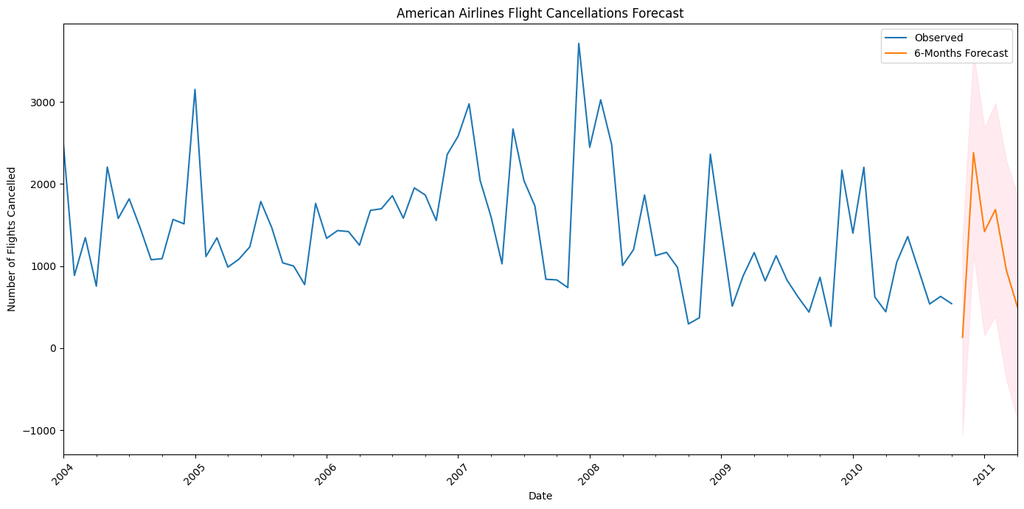

```python
plt.figure(figsize=(14, 7))
american_cancelled_ts.plot(label='Observed', legend=True)
mean_forecast.plot(label='6-Months Forecast', legend=True)
plt.fill_between(confidence_intervals.index,
                 confidence_intervals.iloc[:, 0],
                 confidence_intervals.iloc[:, 1], color='pink', alpha=0.3)
plt.title("American Airlines Flight Cancellations Forecast")
plt.xlabel("Date")
plt.ylabel("Number of Flights Cancelled")
plt.xticks(rotation=45)
plt.tight_layout()
plt.legend()
plt.show()
```

## Next, we will conduct a similar process for the United Airlines Dataset

```python
data_path = '/content/Baggage_Info_United.xlsx'
united_df = pd.read_excel(data_path)
united_df.info()
```

```
<class 'pandas.core.frame.DataFrame'>
RangeIndex: 84 entries, 0 to 83
Data columns (total 8 columns):
 #   Column     Non-Null Count  Dtype
---  ------     --------------  -----
 0   Airline    84 non-null     object
 1   Date       84 non-null     datetime64[ns]
 2   Month      84 non-null     int64
 3   Year       84 non-null     int64
 4   Baggage    84 non-null     int64
 5   Scheduled  84 non-null     int64
 6   Cancelled  84 non-null     int64
 7   Enplaned   84 non-null     int64
dtypes: datetime64[ns](1), int64(6), object(1)
memory usage: 5.4+ KB
```

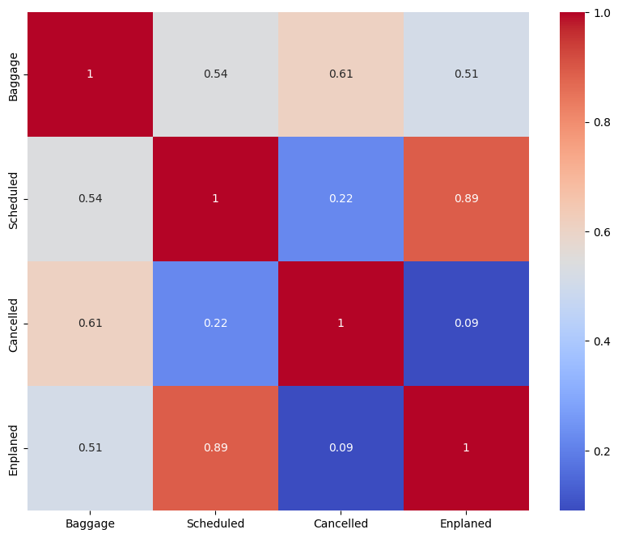

```python
united_bag_dat_sub = united_df.drop(columns=['Airline', 'Date', 'Month', 'Year'])


# Compute correlations
cormat = united_bag_dat_sub.corr()

# Round correlation matrix to 2 decimal places
cormat = cormat.round(2)

# Plot correlation matrix using a heatmap
plt.figure(figsize = (10,8))
sns.heatmap(cormat,annot=True, cmap = 'coolwarm')
plt.show()
```

## We start by looking at the United Airlines Baggage Claim Data

## Create a monthly index for the series

```python
united_df['Date'] = pd.to_datetime(united_df['Date'], format="%b-%y")
united_bag_ts = pd.Series(united_df['Baggage'].values, index=united_df['Date'])
united_bag_ts.index.freq = 'MS'
```

## Plot the series

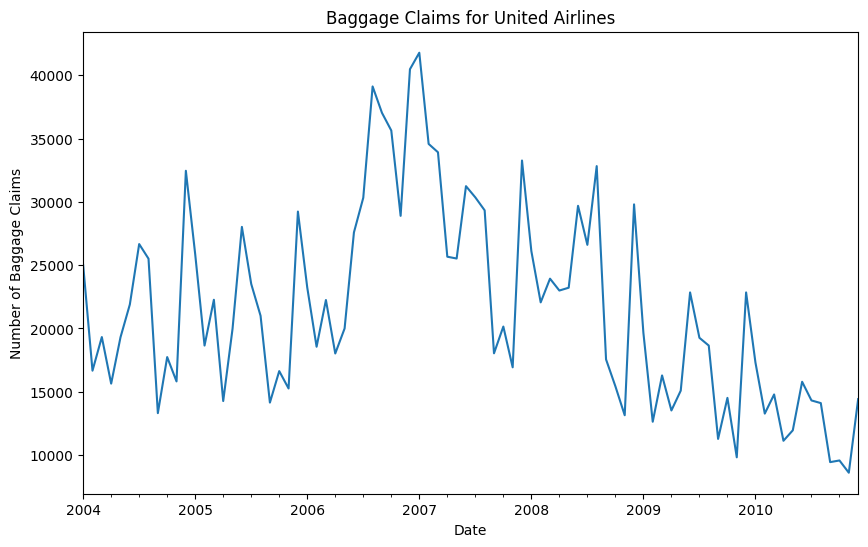

```python
plt.figure(figsize=(10, 6))
united_bag_ts.plot()
plt.title("Baggage Claims for United Airlines")
plt.xlabel("Date")
plt.ylabel("Number of Baggage Claims")
plt.show()
```

## Conduct Ljung Box test on the United Airlines Baggage Claims series using 10 lags to see if the series is white noise

```python
united_bags = united_df[['Baggage']]

sm.stats.acorr_ljungbox(united_bags, lags=[10], return_df=True)
```

|  | lb_stat | lb_pvalue |
| --- | --- | --- |
| 10 | 160.317171 | 2.786746e-29 |

## Since the p-value is near zero, we reject the null hypothesis and conclude that the series is not white noise.

## Next, we will plot the ACF and PACF for the United Airlines Baggage Claims series

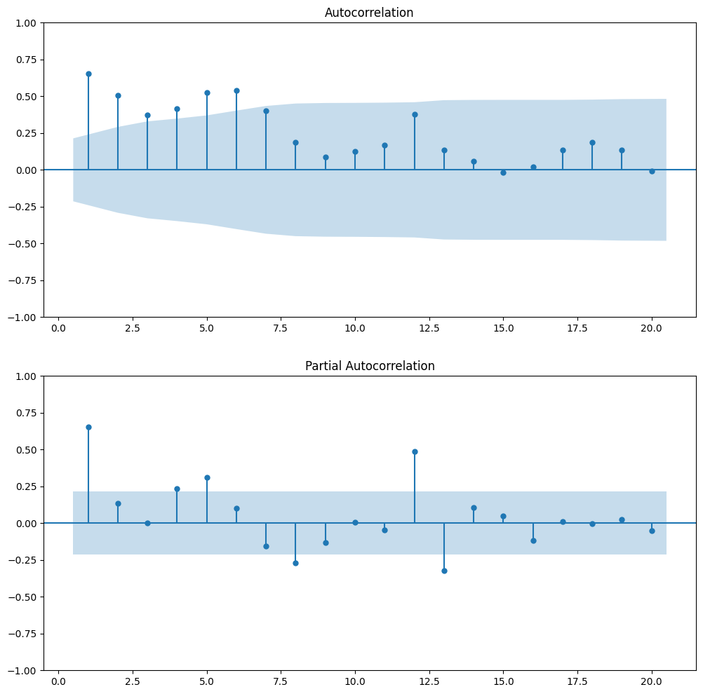

```python
fig, (ax1, ax2) = plt.subplots(2, 1, figsize=(12, 12))
plot_acf(united_bag_ts, ax=ax1, zero=False)
plot_pacf(united_bag_ts, ax=ax2, zero=False)
plt.show()
```

## We see that there is seasonality in the data set, so we will take a 12-month seasonal difference.

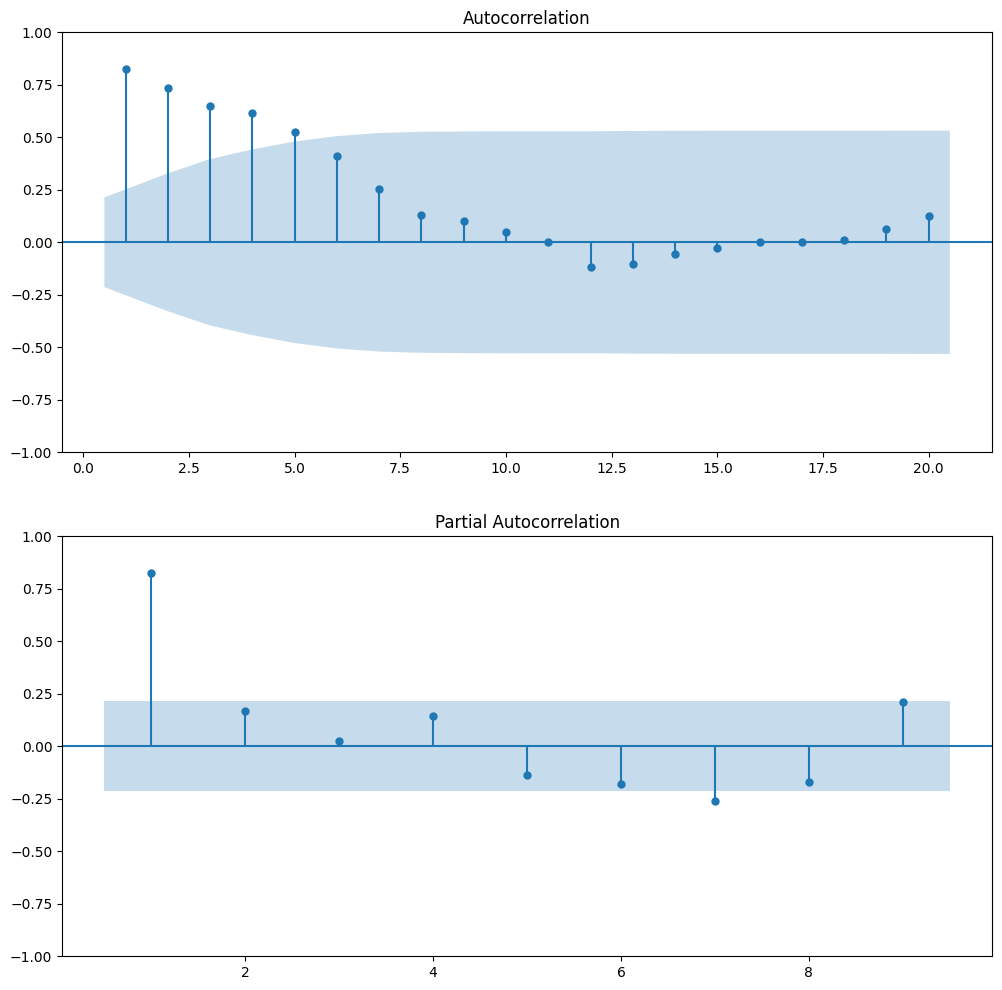

```python
# Fit ARIMA(0,0,0)x(0,1,0)[12] model to the data - This is simply taking the 12-month seasonal difference
#  which is yt - y(t-12)

fit_ARD12 = ARIMA(united_bag_ts, order=(0,0,0), seasonal_order=(0, 1, 0, 12)).fit()

# Plot ACF and PACF for residuals from the seasonal difference in order to
# assess the correlation still remaining in the data

residuals12 = fit_ARD12.resid

fig, (ax1, ax2) = plt.subplots(2, 1, figsize=(12, 12))
plot_acf(residuals12, ax=ax1, zero=False)
plot_pacf(residuals12, ax=ax2, zero=False, lags=9)
plt.show()
```

## Now, we see that by taking a 12-month seasonal difference, our time series has an AR signature.

## We will now fit an ARIMA model to the United Airlines baggage claims time series

```
                                     SARIMAX Results
==========================================================================================
Dep. Variable:                                  y   No. Observations:                   84
Model:             ARIMA(1, 0, 0)x(0, 1, [1], 12)   Log Likelihood                -706.585
Date:                            Mon, 16 Oct 2023   AIC                           1419.170
Time:                                    12:14:41   BIC                           1426.000
Sample:                                01-01-2004   HQIC                          1421.890
                                     - 12-01-2010
Covariance Type:                              opg
==============================================================================
                 coef    std err          z      P>|z|      [0.025      0.975]
------------------------------------------------------------------------------
ar.L1          0.8258      0.035     23.635      0.000       0.757       0.894
ma.S.L12      -0.6496      0.116     -5.580      0.000      -0.878      -0.421
sigma2      1.813e+07   1.72e-09   1.05e+16      0.000    1.81e+07    1.81e+07
===================================================================================
Ljung-Box (L1) (Q):                   0.48   Jarque-Bera (JB):                17.36
Prob(Q):                              0.49   Prob(JB):                         0.00
Heteroskedasticity (H):               0.30   Skew:                            -0.47
Prob(H) (two-sided):                  0.00   Kurtosis:                         5.21
===================================================================================

Warnings:
[1] Covariance matrix calculated using the outer product of gradients (complex-step).
[2] Covariance matrix is singular or near-singular, with condition number 3.51e+31. Standard errors may be unstable.
```

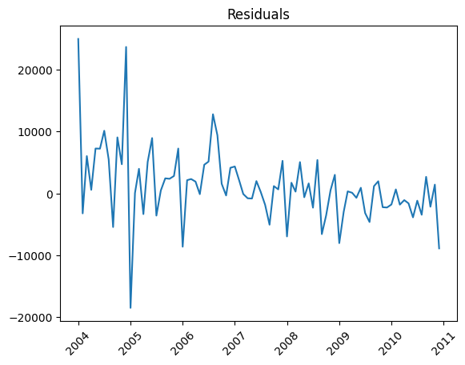

```
<statsmodels.tsa.statespace.mlemodel.PredictionResultsWrapper object at 0x7ac716559de0>
```

```python
# Fit ARIMA(1,0,0)x(0,1,1)[12] model to the data

#Best model for Baggage Complaints for United is ARIMA(1,0,0)x(0,1,1)[12]
fit_AR1 = ARIMA(united_bag_ts, order=(1,0,0), seasonal_order=(0, 1, 1, 12)).fit()

# Summary of the ARIMA model
print(fit_AR1.summary())

# Examine residuals from the model
residuals = fit_AR1.resid
plt.plot(residuals)
plt.title('Residuals')
plt.xticks(rotation=45)
plt.show()

#Generate the predicted values for the series
pred_units = fit_AR1.get_prediction()
print(pred_units)
```

## Plot the ACF and PACF for the residuals

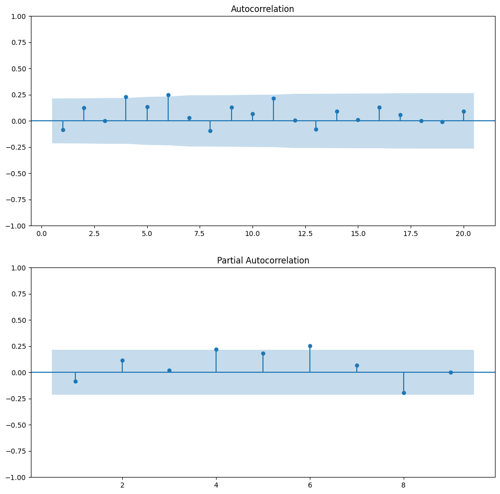

```python
fig, (ax1, ax2) = plt.subplots(2, 1, figsize=(12, 12))
plot_acf(residuals, ax=ax1, zero=False)
plot_pacf(residuals, ax=ax2, zero=False, lags=9)
plt.show()
```

## Conduct a Ljung Box test on the residuals to test for white noise

```python
sm.stats.acorr_ljungbox(residuals, lags=[10], return_df=True)
```

|  | lb_stat | lb_pvalue |
| --- | --- | --- |
| 10 | 16.951913 | 0.075435 |

## Looking at the ACF, PACF, and the results from our Ljung-Box test (fail to reject null hypothesis that the series is white noise because 0.0754 > 0.05), we conclude that this is a reasonable model.

## Next, we will compute the forecast error

```python
predicted_mean = pred_units.predicted_mean
conf_int = pred_units.conf_int()

prediction_df = pd.DataFrame({
    'predicted_mean': predicted_mean,
    'lower_bound': conf_int.iloc[:, 0],
    'upper_bound': conf_int.iloc[:, 1]
})
prediction_df = prediction_df.tail(-1)
prediction_df.head()
```

| Date | predicted_mean | lower_bound | upper_bound |
| --- | --- | --- | --- |
| 2004-02-01 | 19898.744014 | 9639.203017 | 30158.285011 |
| 2004-03-01 | 13278.758482 | 3019.242911 | 23538.274052 |
| 2004-04-01 | 15061.243589 | 4805.267095 | 25317.220083 |
| 2004-05-01 | 12035.958696 | 1785.483779 | 22286.433612 |
| 2004-06-01 | 14649.272687 | 4406.927829 | 24891.617545 |

```python
prediction_df = pd.concat([prediction_df,united_bag_ts.to_frame(name='Baggage')],axis=1)
prediction_df = prediction_df.tail(-1)
prediction_df.head()
```

| Date | predicted_mean | lower_bound | upper_bound | Baggage |
| --- | --- | --- | --- | --- |
| 2004-02-01 | 19898.744014 | 9639.203017 | 30158.285011 | 16660 |
| 2004-03-01 | 13278.758482 | 3019.242911 | 23538.274052 | 19318 |
| 2004-04-01 | 15061.243589 | 4805.267095 | 25317.220083 | 15638 |
| 2004-05-01 | 12035.958696 | 1785.483779 | 22286.433612 | 19302 |
| 2004-06-01 | 14649.272687 | 4406.927829 | 24891.617545 | 21892 |

```python
# calc error
errors = prediction_df['Baggage'] - prediction_df['predicted_mean']
# absolue value of error
errors_abs = errors.abs()
# -- mape --
mape = (errors_abs/prediction_df['Baggage'].abs()).mean()
# -- rmse
rmse = (errors**2).mean()**0.5
# -- print it out
print(f'MAPE = {mape:.3%}')
print(f'RMSE = {rmse:,.3f}')
```

```
MAPE = 17.942%
RMSE = 5,462.825
```

## Our forecast yields a MAPE of 17.942%, which is good in the context of this problem

## Now, we will generate a forecast of baggage claim values for United Airlines for the next 6 months

```python
forecast = fit_AR1.get_forecast(steps=6)
mean_forecast = forecast.predicted_mean
confidence_intervals = forecast.conf_int()
forecast_df = pd.DataFrame({
    'Forecasted_Claims': mean_forecast,
    'Lower_Bound': confidence_intervals.iloc[:, 0],
    'Upper_Bound': confidence_intervals.iloc[:, 1]
})

forecast_df
```

|  | Forecasted_Claims | Lower_Bound | Upper_Bound |
| --- | --- | --- | --- |
| 2011-01-01 | 11517.989987 | 3166.755574 | 19869.224401 |
| 2011-02-01 | 8070.936387 | -2757.702057 | 18899.574831 |
| 2011-03-01 | 11672.924016 | -560.511295 | 23906.359327 |
| 2011-04-01 | 9262.037189 | -3843.209135 | 22367.283512 |
| 2011-05-01 | 11463.779642 | -2204.058916 | 25131.618201 |
| 2011-06-01 | 17903.990424 | 3865.490787 | 31942.490060 |

## Plot the forecast

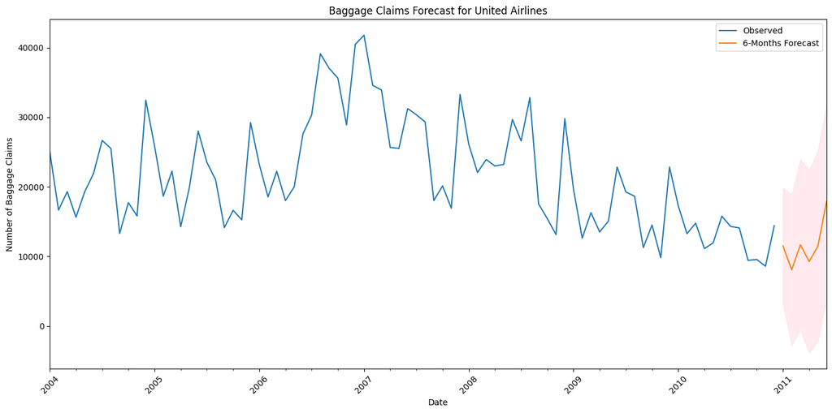

```python
plt.figure(figsize=(14, 7))
united_bag_ts.plot(label='Observed', legend=True)
mean_forecast.plot(label='6-Months Forecast', legend=True)
plt.fill_between(confidence_intervals.index,
                 confidence_intervals.iloc[:, 0],
                 confidence_intervals.iloc[:, 1], color='pink', alpha=0.3)
plt.title("Baggage Claims Forecast for United Airlines")
plt.xlabel("Date")
plt.ylabel("Number of Baggage Claims")
plt.xticks(rotation=45)
plt.tight_layout()
plt.legend()
plt.show()
```

## We will now look at cancelled flight data for United Airlines

```python
# Create a monthly index for the series
united_df['Date'] = pd.to_datetime(united_df['Date'], format="%b-%y")
united_cancelled_ts = pd.Series(united_df['Cancelled'].values, index=united_df['Date'])
united_cancelled_ts.index.freq = 'MS'
```

## Plot the time series

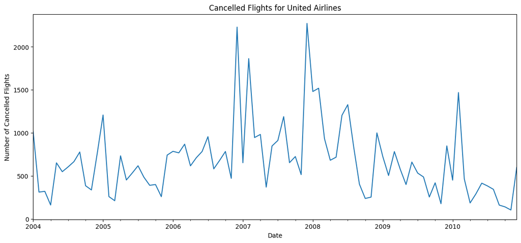

```python
plt.figure(figsize=(14, 6))
united_cancelled_ts.plot()
plt.title("Cancelled Flights for United Airlines")
plt.xlabel("Date")
plt.ylabel("Number of Cancelled Flights")
plt.show()
```

## Conduct Ljung Box test on the United Airlines Cancelled Flight series using 10 lags to see if the series is white noise

```python
united_cancelled = united_df[['Cancelled']]

sm.stats.acorr_ljungbox(united_cancelled, lags=[10], return_df=True)
```

|  | lb_stat | lb_pvalue |
| --- | --- | --- |
| 10 | 37.135304 | 0.000054 |

## Since the p-value is near zero, we reject the null hypothesis and conclude that the series is not white noise.

## Next, we will plot the ACF and PACF for the United Airlines Cancelled Flights series

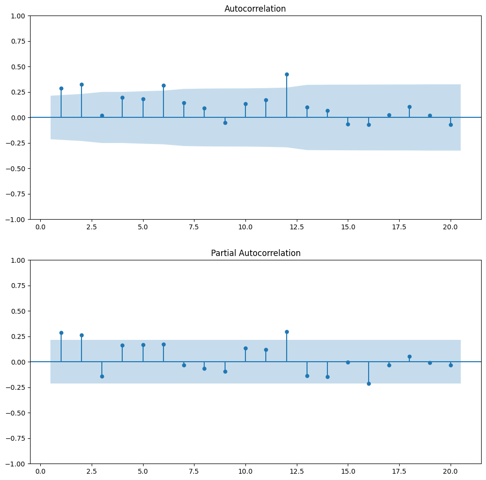

```python
fig, (ax1, ax2) = plt.subplots(2, 1, figsize=(12, 12))
plot_acf(united_cancelled_ts, ax=ax1, zero=False)
plot_pacf(united_cancelled_ts, ax=ax2, zero=False)
plt.show()
```

## Since there is seasonality in this data, we will take a 12-month seasonal difference:

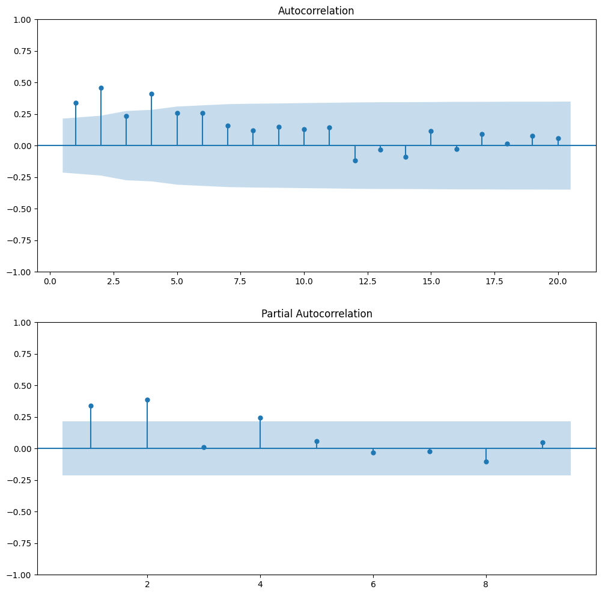

```python
fit_ARD12_united_cancelled = ARIMA(united_cancelled_ts, order=(0,0,0), seasonal_order=(0, 1, 0, 12)).fit()

# Plot ACF and PACF for residuals from the seasonal difference in order to
# assess the correlation still remaining in the data

residuals12_united_cancelled = fit_ARD12_united_cancelled.resid

fig, (ax1, ax2) = plt.subplots(2, 1, figsize=(12, 12))
plot_acf(residuals12_united_cancelled, ax=ax1, zero=False)
plot_pacf(residuals12_united_cancelled, ax=ax2, zero=False, lags=9)
plt.show()
```

## We will fit an ARIMA(0,1,1)x(2,1,0)[12] model to the United Cancelled Flights data:

```
                                     SARIMAX Results
=========================================================================================
Dep. Variable:                                 y   No. Observations:                   84
Model:             ARIMA(0, 1, 1)x(2, 1, [], 12)   Log Likelihood                -520.912
Date:                           Mon, 16 Oct 2023   AIC                           1049.824
Time:                                   12:14:45   BIC                           1058.875
Sample:                               01-01-2004   HQIC                          1053.423
                                    - 12-01-2010
Covariance Type:                             opg
==============================================================================
                 coef    std err          z      P>|z|      [0.025      0.975]
------------------------------------------------------------------------------
ma.L1         -0.7794      0.076    -10.299      0.000      -0.928      -0.631
ar.S.L12      -0.3983      0.106     -3.740      0.000      -0.607      -0.190
ar.S.L24      -0.3980      0.106     -3.754      0.000      -0.606      -0.190
sigma2      1.276e+05    1.9e+04      6.712      0.000    9.03e+04    1.65e+05
===================================================================================
Ljung-Box (L1) (Q):                   1.45   Jarque-Bera (JB):                13.59
Prob(Q):                              0.23   Prob(JB):                         0.00
Heteroskedasticity (H):               0.58   Skew:                             0.71
Prob(H) (two-sided):                  0.19   Kurtosis:                         4.61
===================================================================================

Warnings:
[1] Covariance matrix calculated using the outer product of gradients (complex-step).
```

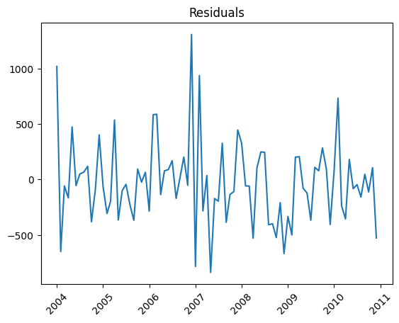

```
<statsmodels.tsa.statespace.mlemodel.PredictionResultsWrapper object at 0x7ac7123f03d0>
```

```python
fit_AR1_cancelled = ARIMA(united_cancelled_ts, order=(0,1,1), seasonal_order=(2, 1, 0, 12)).fit()

# Summary of the ARIMA model
print(fit_AR1_cancelled.summary())

# Examine residuals from the model
residuals = fit_AR1_cancelled.resid
plt.plot(residuals)
plt.title('Residuals')
plt.xticks(rotation=45)
plt.show()

#Generate the predicted values for the series
pred_units = fit_AR1_cancelled.get_prediction()
print(pred_units)
```

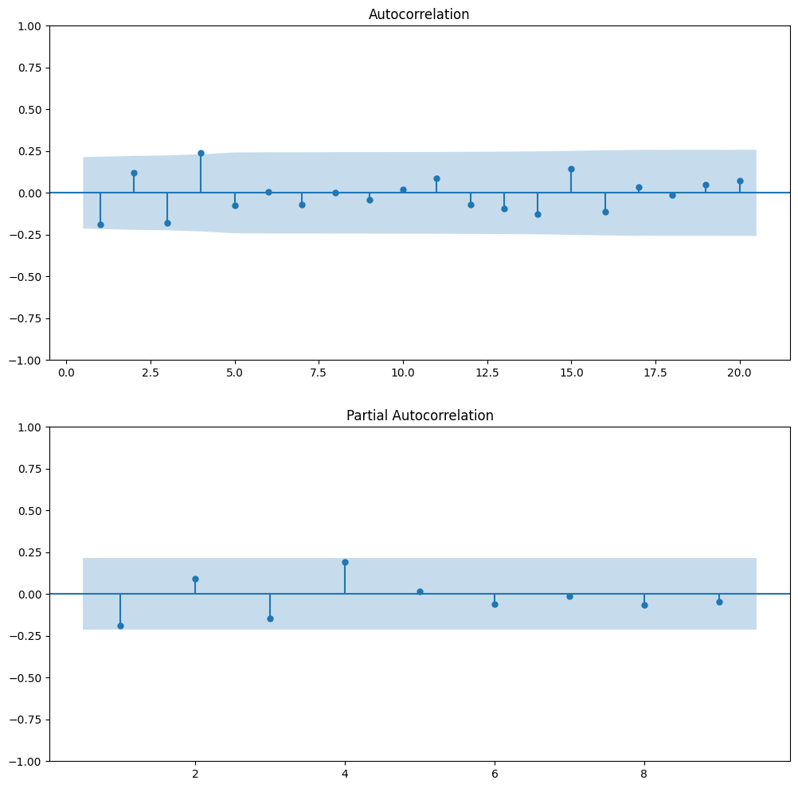

```python
# Plot ACF and PACF for residuals
fig, (ax1, ax2) = plt.subplots(2, 1, figsize=(12, 12))
plot_acf(residuals, ax=ax1, zero=False)
plot_pacf(residuals, ax=ax2, zero=False, lags=9)
plt.show()
```

## Conduct a Ljung-Box test on the residuals

```python
sm.stats.acorr_ljungbox(residuals, lags=[10], return_df=True)
```

|  | lb_stat | lb_pvalue |
| --- | --- | --- |
| 10 | 13.631259 | 0.190485 |

## Looking at the ACF, PACF, and Ljung-Box test (fail to reject the null hypothesis that the series is white noise since 0.190 > 0.05), we conclude that this is a reasonable model

## Next, we will compute the forecast error

```python
predicted_mean = pred_units.predicted_mean
conf_int = pred_units.conf_int()

prediction_df = pd.DataFrame({
    'predicted_mean': predicted_mean,
    'lower_bound': conf_int.iloc[:, 0],
    'upper_bound': conf_int.iloc[:, 1]
})
prediction_df = prediction_df.tail(-1)
prediction_df.head()
```

| Date | predicted_mean | lower_bound | upper_bound |
| --- | --- | --- | --- |
| 2004-02-01 | 959.262964 | -1238.987669 | 3157.513596 |
| 2004-03-01 | 378.171279 | -1814.965174 | 2571.307731 |
| 2004-04-01 | 326.872050 | -1866.210639 | 2519.954740 |
| 2004-05-01 | 178.934805 | -2014.147317 | 2372.016927 |
| 2004-06-01 | 603.409162 | -1589.672954 | 2796.491278 |

```python
prediction_df = pd.concat([prediction_df,united_cancelled_ts.to_frame(name='Cancelled')],axis=1)
prediction_df = prediction_df.tail(-1)
prediction_df.head()
```

| Date | predicted_mean | lower_bound | upper_bound | Cancelled |
| --- | --- | --- | --- | --- |
| 2004-02-01 | 959.262964 | -1238.987669 | 3157.513596 | 312 |
| 2004-03-01 | 378.171279 | -1814.965174 | 2571.307731 | 321 |
| 2004-04-01 | 326.872050 | -1866.210639 | 2519.954740 | 162 |
| 2004-05-01 | 178.934805 | -2014.147317 | 2372.016927 | 652 |
| 2004-06-01 | 603.409162 | -1589.672954 | 2796.491278 | 549 |

## Calculate MAPE and RMSE

```python
# calc error
errors = prediction_df['Cancelled'] - prediction_df['predicted_mean']
# absolue value of error
errors_abs = errors.abs()
# -- mape --
mape = (errors_abs/prediction_df['Cancelled'].abs()).mean()
# -- rmse
rmse = (errors**2).mean()**0.5
# -- print it out
print(f'MAPE = {mape:.3%}')
print(f'RMSE = {rmse:,.3f}')
```

```
MAPE = 49.878%
RMSE = 360.087
```

## Our forecast yields a MAPE of 49.878% and an RMSE of 360.087, which is a reasonable model considering how much randomness there is in flight cancellations.

## Next, we will generate forecast values

```python
forecast = fit_AR1_cancelled.get_forecast(steps=6)
mean_forecast = forecast.predicted_mean
confidence_intervals = forecast.conf_int()
forecast_df = pd.DataFrame({
    'Forecasted_Cancellations': mean_forecast,
    'Lower_Bound': confidence_intervals.iloc[:, 0],
    'Upper_Bound': confidence_intervals.iloc[:, 1]
})

forecast_df
```

|  | Forecasted_Cancellations | Lower_Bound | Upper_Bound |
| --- | --- | --- | --- |
| 2011-01-01 | 454.225225 | -245.886873 | 1154.337323 |
| 2011-02-01 | 1081.830911 | 364.880804 | 1798.781018 |
| 2011-03-01 | 244.948178 | -488.453460 | 978.349817 |
| 2011-04-01 | -23.284993 | -772.777134 | 726.207149 |
| 2011-05-01 | 54.776448 | -710.467942 | 820.020838 |
| 2011-06-01 | 322.896162 | -457.782699 | 1103.575022 |

## We will now plot our predicted values for United Airlines flight cancellations for the next 6 months

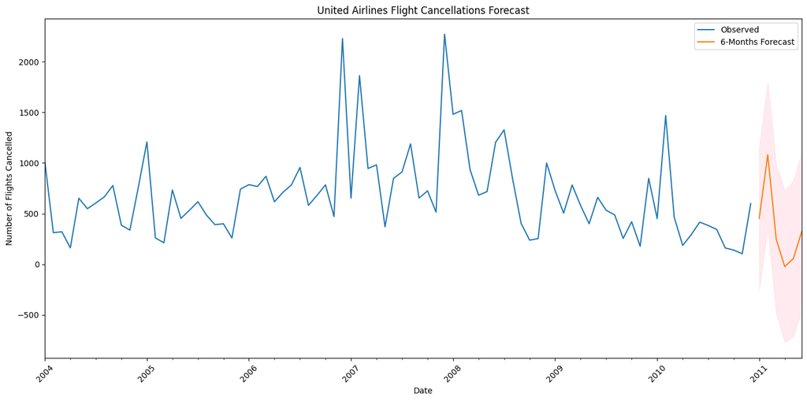

```python
plt.figure(figsize=(14, 7))
united_cancelled_ts.plot(label='Observed', legend=True)
mean_forecast.plot(label='6-Months Forecast', legend=True)
plt.fill_between(confidence_intervals.index,
                 confidence_intervals.iloc[:, 0],
                 confidence_intervals.iloc[:, 1], color='pink', alpha=0.3)
plt.title("United Airlines Flight Cancellations Forecast")
plt.xlabel("Date")
plt.ylabel("Number of Flights Cancelled")
plt.xticks(rotation=45)
plt.tight_layout()
plt.legend()
plt.show()
```

## For additional analysis, let's look at the proportion of flights cancelled by airline compared to scheduled

```python
proportion_cancelled_united = (united_df['Cancelled'] / united_df["Scheduled"]) * 100
proportion_cancelled_united.median()
```

```
1.603153879561992
```

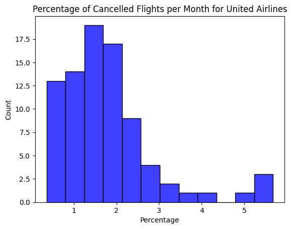

```python
sns.histplot(proportion_cancelled_united, color='blue')
plt.title("Percentage of Cancelled Flights per Month for United Airlines")
plt.xlabel("Percentage")
plt.ylabel("Count")
plt.show()
```

```python
proportion_cancelled_american = (american_df['Cancelled'] / american_df["Scheduled"]) * 100
proportion_cancelled_american.median()
```

```
3.104319677026
```

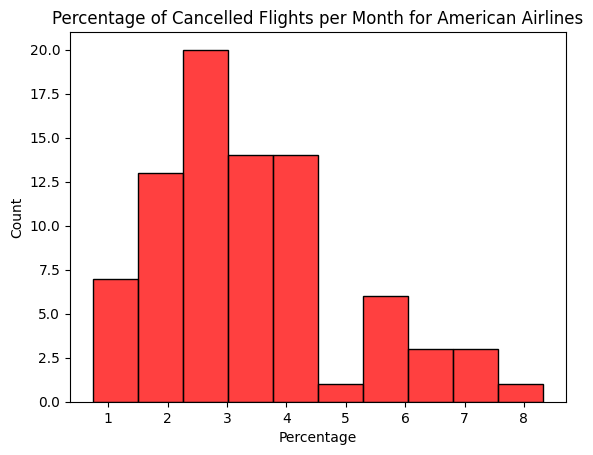

```python
sns.histplot(proportion_cancelled_american, color='red')
plt.title("Percentage of Cancelled Flights per Month for American Airlines")
plt.xlabel("Percentage")
plt.ylabel("Count")
plt.show()
```

```python
proportion_baggage_united = (united_df['Baggage'] / united_df["Enplaned"]) * 100
proportion_baggage_united.median()
```

```
0.4207663645402847
```

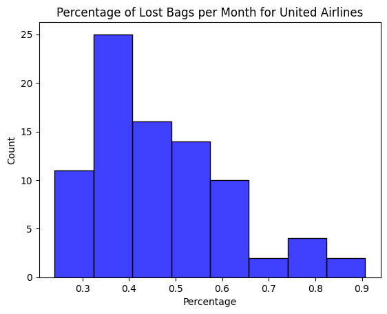

```python
sns.histplot(proportion_baggage_united, color='blue')
plt.title("Percentage of Lost Bags per Month for United Airlines")
plt.xlabel("Percentage")
plt.ylabel("Count")
plt.show()
```

```python
proportion_baggage_american = (american_df['Baggage'] / american_df["Enplaned"]) * 100
proportion_baggage_american.median()
```

```
0.9577020731554542
```

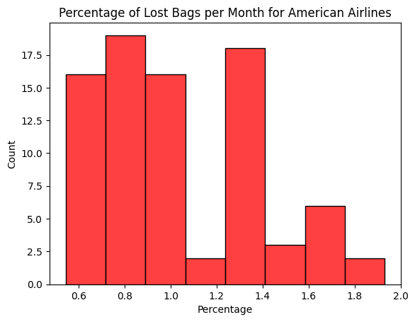

```python
sns.histplot(proportion_baggage_american, color='red')
plt.title("Percentage of Lost Bags per Month for American Airlines")
plt.xlabel("Percentage")
plt.ylabel("Count")
plt.show()
```

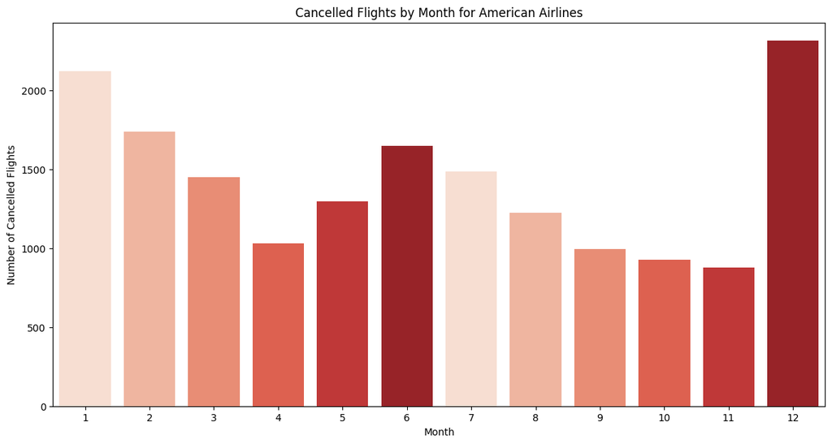

```python
palette = sns.color_palette('Reds')
plt.figure(figsize=(14, 7))
sns.barplot(american_df, x='Month', y='Cancelled', errorbar=None, palette=palette)
plt.title("Cancelled Flights by Month for American Airlines")
plt.xlabel("Month")
plt.ylabel("Number of Cancelled Flights")
plt.show()
```